# 2 Introducción

## 2.1 Introducción y Comprensión del Negocio

### 2.1.1 Justificación del Proyecto

El rendimiento académico es un indicador fundamental del éxito educativo, y su análisis permite identificar factores clave que afectan el desempeño de los estudiantes. Este proyecto busca no solo predecir resultados académicos, sino también proporcionar una base sólida para la toma de decisiones orientadas a mejorar la calidad educativa. Al identificar patrones en los datos, es posible diseñar estrategias específicas que beneficien a estudiantes en riesgo, optimicen los recursos disponibles y promuevan la equidad en el acceso a oportunidades educativas. Este enfoque basado en evidencia destaca la importancia de utilizar herramientas analíticas modernas para enfrentar desafíos educativos complejos de manera eficiente y práctica.

### 2.1.2 CRISP-DM como Metodología

En este proyecto seguiremos el marco de referencia **CRISP-DM (Cross Industry Standard Process for Data Mining)**, que ofrece un enfoque estructurado para proyectos de análisis de datos. Este modelo se compone de las siguientes fases:

- **Comprensión del negocio:** Identificar los objetivos y necesidades del análisis desde una perspectiva práctica.
- **Comprensión de los datos:** Explorar los datos disponibles, evaluar su calidad y determinar cómo pueden contribuir al problema.
- **Preparación de los datos:** Limpiar, transformar y seleccionar las variables relevantes para el análisis.
- **Modelado:** Aplicar algoritmos para generar resultados que permitan extraer patrones o predicciones.
- **Evaluación:** Validar si los resultados obtenidos cumplen con los objetivos del negocio.
- **Implementación:** Traducir los resultados en acciones o herramientas prácticas.

Este enfoque garantiza que el proyecto esté alineado con las necesidades del negocio y permita obtener resultados prácticos y efectivos.

### 2.1.3 Problema de Negocio y Preguntas de Investigación

**Decisión del Negocio:**

Las instituciones educativas buscan comprender los factores que más influyen en el rendimiento académico de los estudiantes. El objetivo es predecir el desempeño estudiantil y diseñar estrategias de intervención para apoyar a aquellos en riesgo de bajo rendimiento. Este análisis permitirá identificar las áreas de mejora y optimizar el uso de recursos educativos.

**Preguntas de Investigación:**

- ¿Cuáles son los factores más importantes que afectan las calificaciones finales de los estudiantes?
- ¿Se puede predecir el rendimiento académico en función de características internas o personales, externos o familiares y escolares de los estudiantes?
- ¿Cómo podemos segmentar a los estudiantes en grupos según características similares para diseñar estrategias personalizadas?

### 2.1.4 Objetivos

**Objetivo General:**

Desarrollar un modelo predictivo para identificar los factores clave en el rendimiento académico de los estudiantes y prever el desempeño en exámenes finales.

**Objetivos Específicos:**

- Seleccionar y analizar variables representativas de los factores internos o personales, externos o familiares y escolares que afectan el rendimiento académico.
- Evaluar las variables seleccionadas para determinar si realizar un análisis de regresión o correlación, dependiendo de lo que sea más adecuado para identificar relaciones significativas y relevantes en el contexto del rendimiento académico.
- Aplicar técnicas de clustering para descubrir posibles patrones y agrupaciones entre los estudiantes, segmentándolos según características clave.
- Documentar los resultados y análisis en un reporte generado en R Markdown o Quarto Book, con explicaciones claras y estructuradas.
- Desarrollar un informe interactivo en FlexDashboard, destacando los principales hallazgos y visualizaciones del análisis.

### 2.1.5 Fuentes de Datos

**Descripción del Dataset:**

El dataset `“StudentPerformanceFactors.csv”` contiene información sobre diversos factores que influyen en el rendimiento académico de los estudiantes, con un total de 6,607 filas y 20 columnas. La variable objetivo de este análisis es la calificación final o puntuación del examen (`Exam_Score`).

**Variables Seleccionadas:**

El análisis considerará variables representativas de los siguientes ámbitos:

- **Factores Internos o Personales:** Incluyendo características personales del estudiante como horas de estudio, nivel de motivación, hábitos de sueño y asistencia a clases.
- **Factores Externos de Apoyo Familiar o de Terceros:** Como el nivel de participación de los padres en la educación, su nivel educativo o el apoyo de tutores.
- **Factores Dependientes de la Escuela:** Tales como el tipo de escuela y la calidad percibida de los profesores.

Las variables finales seleccionadas para el modelado y análisis profundo se determinarán tras un análisis exploratorio de datos (EDA), en función de su relevancia y contribución al problema planteado.

**Fuente del Dataset:** Kaggle  
[Dataset aquí](https://www.kaggle.com/datasets/lainguyn123/student-performance-factors)

### 2.1.6 Plan de Trabajo

La siguiente tabla describe el cronograma del proyecto en semanas:

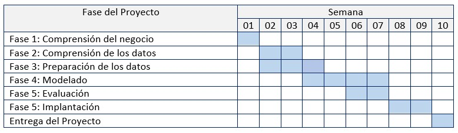

### 2.1.7 Metodología

El enfoque metodológico se basará en las fases de CRISP-DM (Cross-Industry Standard Process for Data Mining), adaptado al contexto del análisis del rendimiento académico de estudiantes. Estas fases guiarán el trabajo y garantizarán un flujo estructurado y lógico en el desarrollo del proyecto.

#### 2.1.7.1 Comprensión del negocio

- Identificar las necesidades educativas y los objetivos del análisis: predecir el rendimiento académico, segmentar a los estudiantes y destacar factores clave que influyen en las calificaciones o puntuaciones de examen.
- Traducir estos objetivos en preguntas específicas:
  - ¿Cuáles son los factores más relevantes?
  - ¿Qué estrategias de intervención se pueden diseñar a partir de los resultados?

#### 2.1.7.2 Comprensión de los datos

- Exploración inicial del dataset para identificar su estructura, distribución de variables y posibles problemas de calidad (valores faltantes, atípicos, duplicados, etc.).
- Descripción general de las características de los estudiantes, incluyendo distribuciones por género, tipo de escuela, y nivel educativo de los padres, entre otros.

#### 2.1.7.3 Preparación de los datos

- Realizar limpieza de datos:
  - Manejo de valores faltantes mediante imputación o exclusión dependiendo del contexto.
  - Identificación y tratamiento de valores atípicos que puedan influir en los resultados del análisis.
  - Corrección de inconsistencias en los datos y eliminación de duplicados.
- Transformar las variables relevantes en formatos adecuados para el análisis (como codificación de variables categóricas).
- Seleccionar las variables representativas de los factores internos o personales, externos y dependientes de la escuela para los análisis posteriores.

#### 2.1.7.4 Análisis exploratorio de datos (EDA)

- Visualizar la distribución de la variable objetivo (`Exam_Score`) y otras variables relevantes mediante gráficos (histogramas, diagramas de dispersión, gráficos de cajas, etc.).
- Evaluar relaciones iniciales entre variables para identificar patrones generales y posibles correlaciones significativas.

#### 2.1.7.5 Modelado

- **Regresión o Correlación:** Dependiendo de los resultados del EDA, se decidirá si realizar un análisis de regresión lineal o un análisis de correlación. Solo se aplicará uno de ellos, según el que aporte mayor valor para comprender las relaciones entre las variables.
- **Clustering:** Se aplicará clustering para identificar agrupaciones naturales de estudiantes, considerando las variables seleccionadas en la preparación de los datos. Esto permitirá segmentar a los estudiantes y descubrir patrones en función de sus características.

#### 2.1.7.6 Evaluación

- Validar los resultados obtenidos en las fases anteriores, asegurando que responden a los objetivos iniciales.
- Analizar si las segmentaciones y patrones identificados son consistentes y útiles para tomar decisiones educativas.

#### 2.1.7.7 Implementación (Entregables)

- Generar un informe técnico en **R Markdown** o **Quarto Book**, documentando todo el análisis y resultados.
- Crear un informe visual interactivo utilizando **FlexDashboard**, destacando los hallazgos más relevantes para facilitar su interpretación final.

### 2.1.8 Tecnología

**Gestión de Datos:**

El Dataset fue descargado de Kaggle, aparentemente ya preprocesado. La transformación de datos se realizará utilizando R.

**Lenguaje de Programación y Librerías:**

- R: Utilizado como lenguaje principal para el análisis estadístico, manipulación de datos y visualización.
- Librerías Relevantes:
1. **`dplyr`**: Manipulación eficiente de datos.
2. **`ggplot2`**: Creación de gráficos personalizables y de alta calidad.
3. **`tidyr`**: Transformación y ordenamiento de datos.
4. **`corrplot`**: Visualización de matrices de correlación.
5. **`caret`**: Entrenamiento y validación de modelos predictivos.
6. **`broom`**: Resumen y conversión de modelos estadísticos en tibbles.
7. **`fastDummies`**: Generación de variables dummy para codificación categórica.
8. **`car`**: Evaluación de supuestos estadísticos, como colinealidad y homocedasticidad.
9. **`lmtest`**: Pruebas de hipótesis en modelos lineales, como Breusch-Pagan.
10. **`patchwork`**: Composición de múltiples gráficos en una sola visualización.
11. **`kableExtra`**: Creación de tablas estilizadas para informes.

**Plataforma de Desarrollo:**

RStudio para desarrollo, ejecución de código y generación de informes en R Markdown y FlexDashboard.

**Control de Versiones:**

Uso de GitHub para documentar el progreso y mantener el historial de versiones en:

`https://github.com/SolFlor/ProyectoCienciaDeDatos/`